# Reproducible Research: Peer Assessment 1

## Loading and preprocessing the data

Load library

```r
library(dplyr)
```

```r
library(ggplot2)
library(lubridate)
```

Read the data and assign it’s content to “activity”

```r
activity <- read.table(unz("activity.zip", "activity.csv"), header=T, sep=",")
print("See preview of loaded data")
```

```
## [1] "See preview of loaded data"
```

```r
head (activity)
```

```
##   steps       date interval
## 1    NA 2012-10-01        0
## 2    NA 2012-10-01        5
## 3    NA 2012-10-01       10
## 4    NA 2012-10-01       15
## 5    NA 2012-10-01       20
## 6    NA 2012-10-01       25
```

Process or transform the date field into the format "Year-Month-Day

```r
activity$date <- as.Date(activity$date, format = "%Y-%m-%d")
```

## What is mean total number of steps taken per day?

Compute total number of steps taken each day

```r
totalsteps <- activity %>% group_by(date) %>% summarise(total.steps = sum(steps, na.rm = TRUE))
head(tibble(totalsteps))
```

```
## # A tibble: 6 x 2
##   date       total.steps
##   <date>           <int>
## 1 2012-10-01           0
## 2 2012-10-02         126
## 3 2012-10-03       11352
## 4 2012-10-04       12116
## 5 2012-10-05       13294
## 6 2012-10-06       15420
```

Histogram of the number of steps taken each day

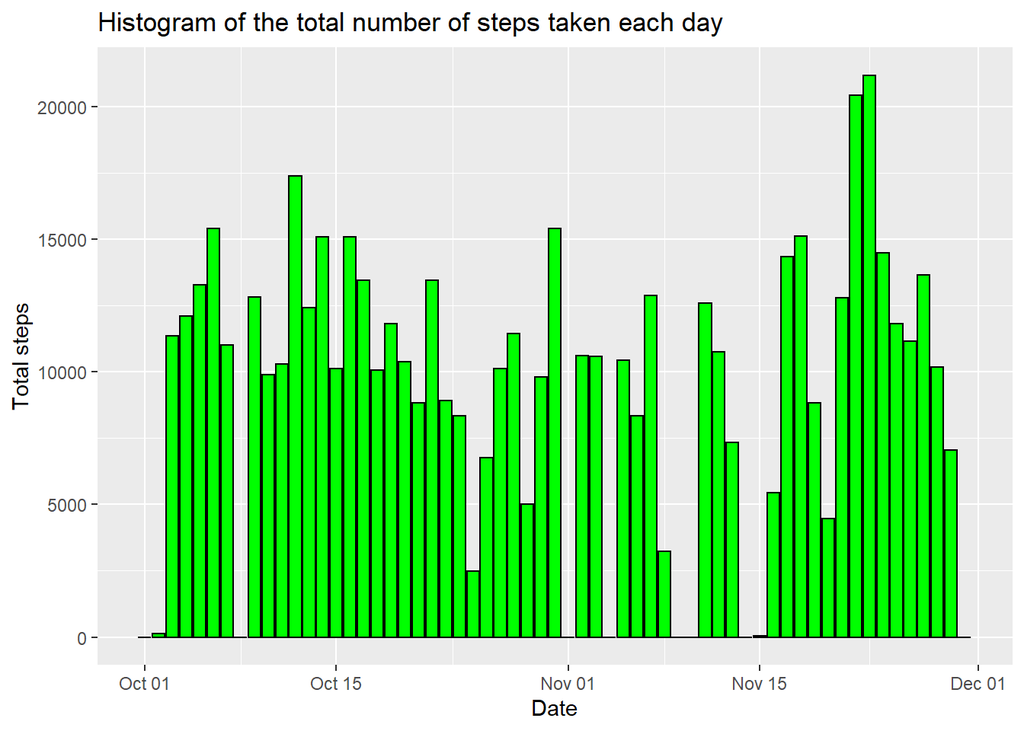

```r
g <- ggplot(totalsteps, aes(x = date, y = total.steps))
g <- g + geom_histogram(stat = "identity", colour = " black", fill = "green")
g <- g + labs(title = "Histogram of the total number of steps taken each day", x = "Date", y = "Total steps")
print(g)
```

Compute the mean of number of steps taken each day

```r
mean <- mean(totalsteps$total.steps, na.rm = TRUE)
mean
```

```
## [1] 9354.23
```

Compute the median of number of steps taken each day

```r
median <- median(totalsteps$total.steps, na.rm = TRUE)
median
```

```
## [1] 10395
```

## Average daily activity pattern?

Compute daily average steps

```r
averagesteps <- activity %>% group_by(interval) %>% summarise(avg.steps = mean(steps, na.rm = TRUE))
head(tibble(averagesteps))
```

```
## # A tibble: 6 x 2
##   interval avg.steps
##      <int>     <dbl>
## 1        0    1.72
## 2        5    0.340
## 3       10    0.132
## 4       15    0.151
## 5       20    0.0755
## 6       25    2.09
```

Plot time series

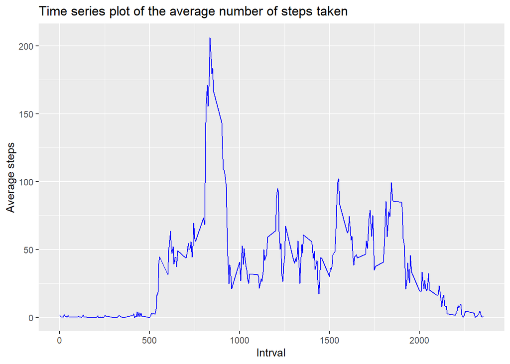

```r
g <- ggplot(averagesteps, aes(x = interval, y = avg.steps))
g <- g + geom_line(stat = "identity", col = "blue")
g <- g + labs(title = "Time series plot of the average number of steps taken", x = "Intrval", y = "Average steps")

print(g)
```

Compute the interval with the maximum number of steps on average

```r
intwthmaxsteps <- averagesteps$interval[averagesteps$avg.steps == max(averagesteps$avg.steps)]
intwthmaxsteps
```

```
## [1] 835
```

## Imputing missing values

Total number of missing values in data set

```r
missingvalue <- activity[is.na(activity) == TRUE]
length(missingvalue)
```

```
## [1] 2304
```

## Method of of filling in missing values

The method used is to group all data according to their 5-minute intervals. The means of the 5-minute intervals are computed without NAs. The respective mean values are assigned to all locations where NA is true.

```r
fills <-  function(x){
                 x$steps[is.na(x$steps)] <- ave(x$steps, x$interval, FUN = function(z)
                 mean(z, na.rm = TRUE))[c(which(is.na(x$steps)))]
return(x)
}
activity_fld <- fills(activity)
head(tibble(activity_fld))
```

```
## # A tibble: 6 x 3
##    steps date       interval
##    <dbl> <date>        <int>
## 1 1.72   2012-10-01        0
## 2 0.340  2012-10-01        5
## 3 0.132  2012-10-01       10
## 4 0.151  2012-10-01       15
## 5 0.0755 2012-10-01       20
## 6 2.09   2012-10-01       25
```

Histogram view of the number of steps taken each day over filled data

```r
totalsteps2 <- activity_fld %>% group_by(date) %>% summarise(total.steps = sum(steps))
head(tibble(totalsteps2))
```

```
## # A tibble: 6 x 2
##   date       total.steps
##   <date>           <dbl>
## 1 2012-10-01      10766.
## 2 2012-10-02        126
## 3 2012-10-03      11352
## 4 2012-10-04      12116
## 5 2012-10-05      13294
## 6 2012-10-06      15420
```

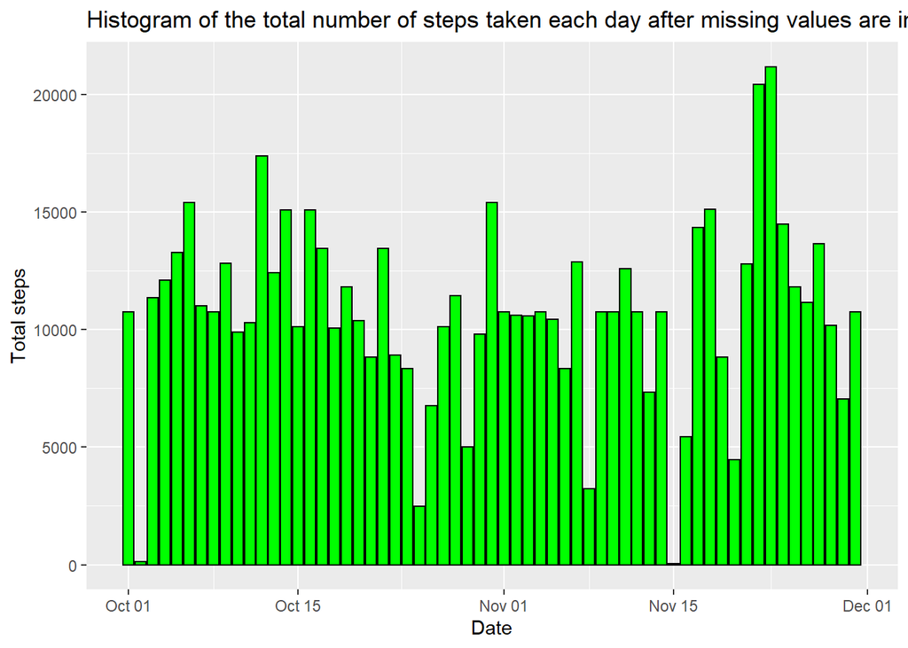

```r
## Plotting total steps
g <- ggplot(totalsteps2, aes(x = date, y = total.steps))
g <- g + geom_histogram(stat = "identity", colour = " black", fill = "green")
g <- g + labs(title = "Histogram of the total number of steps taken each day after missing values are imputed", x = "Date", y = "Total steps")
print(g)
```

Compute the new mean of number of steps per day

```r
mean <- mean(totalsteps2$total.steps)

mean
```

```
## [1] 10766.19
```

Compute the new median of number of steps per day

```r
median <- median(totalsteps2$total.steps)
median
```

```
## [1] 10766.19
```

The new mean and median are different from the original ones computed by removing NAs.

## Are there differences in activity patterns between weekdays and weekends?

The activity patterns between the weekday and weekends are different. See figure below:

```r
activity_fld$wk_days <- weekdays(as.Date(activity_fld$date))

i = 1

for (i in 1:length(activity_fld$wk_days)){
    if(activity_fld$wk_days[i] == "Saturday"|activity_fld$wk_days[i] == "Sunday"){
        activity_fld$wk_grp[i] <- "Weekend"
    } else {
      activity_fld$wk_grp[i] <- "Weekday"
      }
}

averagesteps2 <- activity_fld %>% group_by(interval, wk_grp) %>% summarise(avg.steps = mean(steps, na.rm = TRUE))
head(tibble(averagesteps2))
```

```
## # A tibble: 6 x 3
##   interval wk_grp  avg.steps
##      <int> <chr>       <dbl>
## 1        0 Weekday    2.25
## 2        0 Weekend    0.215
## 3        5 Weekday    0.445
## 4        5 Weekend    0.0425
## 5       10 Weekday    0.173
## 6       10 Weekend    0.0165
```

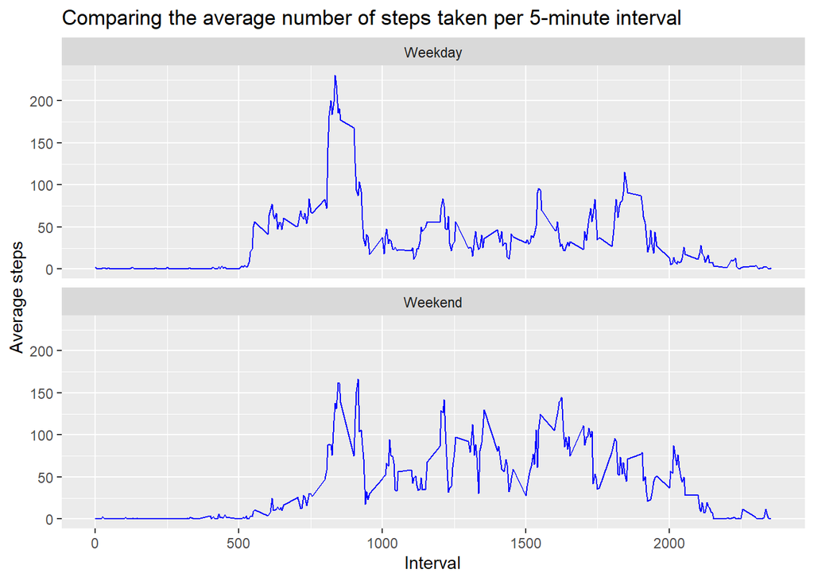

```r
library(lattice)
g <- ggplot(averagesteps2, aes(x = interval, y = avg.steps))
g <- g + geom_line(stat = "identity", col = "blue")
g <- g + facet_wrap(~ wk_grp, ncol = 1)
g <- g + labs(title = "Comparing the average number of steps taken per 5-minute interval", x = "Interval", y ="Average steps")
print(g)
```